# Introduction to Multivariable Functional Mendelian Randomization

Nicole Fontana

2026-07-14

## Overview

This vignette introduces **Multivariable Functional Mendelian Randomization (MV-FMR)**, a method to estimate time-varying causal effects of multiple correlated longitudinal exposures on health outcomes.

### Key Features

- **Joint estimation** of an arbitrary number of time-varying exposures
- Automatic component selection via cross-validation
- Support for continuous and binary outcomes
- Bootstrap inference for confidence intervals
- Instrument strength diagnostics

### When to Use MV-FMR

Use joint multivariable estimation (`mvfmr()`) when:

- You have **multiple exposures** that may be correlated
- Exposures may share **horizontal pleiotropy** (common genetic variants)
- There may be **mediation** between exposures
- You want to estimate **independent causal effects** of each exposure

## Installation

```r
# Install from CRAN
install.packages("mvfmr")
```

```r
library(mvfmr)
library(fdapace)
library(ggplot2)
```

## Example: Joint Estimation of Two Exposures

### Step 1: Simulate Data

We generate genetic instruments and two longitudinal exposures:

```r
set.seed(473920)

# Generate exposure data
sim_data <- getX_multi_exposure(
  N = 300,              # Sample size
  J = 25,               # Number of genetic instruments
  nSparse = 10,          # Observations per subject
  n_exposures = 2        # Number of exposures (m)
)

# Check dimensions
cat("Sample size:", nrow(sim_data$details$G), "\n")
```

```
#> Sample size: 300
```

```r
cat("Number of instruments:", ncol(sim_data$details$G), "\n")
```

```
#> Number of instruments: 25
```

### Step 2: Generate Outcome

We create an outcome with **linear effect** from exposure 1 and exposure 2:

```r
outcome_data <- getY_multi_exposure(
  sim_data,
  XYmodels = c("2", "2"),     # Exposure 1/2: linear beta(t) = 0.02*t
  X_effects = c(TRUE, TRUE),
  outcome_type = "continuous"
)

cat("Outcome summary:\n")
```

```
#> Outcome summary:
```

```r
summary(outcome_data$Y)
```

```
#>    Min. 1st Qu.  Median    Mean 3rd Qu.    Max.
#> -236.50  -71.40  -26.03  -23.83   28.53  182.65
```

### Step 3: Functional Principal Component Analysis

We apply FPCA to each exposure to extract principal components:

```r
fpca_results <- lapply(sim_data$exposures, function(exp_k) {
  FPCA(
    exp_k$Ly_sim,
    exp_k$Lt_sim,
    list(dataType = 'Sparse', error = TRUE, verbose = FALSE)
  )
})

cat("FPCA completed:\n")
```

```
#> FPCA completed:
```

```r
for (k in seq_along(fpca_results)) {
  cat("  Exposure", k, ":", fpca_results[[k]]$selectK, "components selected\n")
}
```

```
#>   Exposure 1 : 3 components selected
#>   Exposure 2 : 3 components selected
```

### Step 4: Joint Multivariable Estimation

Now we perform joint estimation using `mvfmr()`. All exposure-related arguments (`fpca_results`, `max_nPC`, `true_effects`, `X_true`, …) are lists or vectors of length m, one entry per exposure:

```r
result_joint <- mvfmr(
  G = sim_data$details$G,
  fpca_results = fpca_results,
  Y = outcome_data$Y,
  outcome_type = "continuous",
  method = "gmm",
  max_nPC = c(4, 4),
  improvement_threshold = 0.001,
  bootstrap = FALSE,
  n_cores = 1,
  true_effects = c("2", "2"),
  X_true = sim_data$details$X_list,
  verbose = FALSE
)

# View results
print(result_joint)
```

```
#>
#> Functional Multivariable MR Result
#> ==================================
#> Exposures: 2
#> Sample size: 300
#> Outcome: continuous
#> Method: gmm
#> Components selected: nPC1 = 2, nPC2 = 2
#>
#> Performance Metrics:
#>   Exposure 1 - MISE: 0.002458 , Coverage: 1
#>   Exposure 2 - MISE: 0.003881 , Coverage: 0.745
```

### Step 5: Visualize Time-Varying Effects

The estimated time-varying causal effects can be visualized using the built-in plot method:

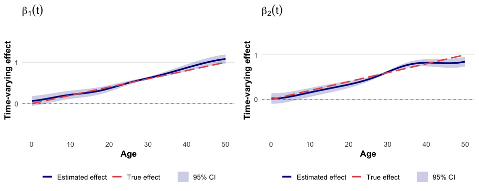

```r
# Plot every exposure's effect
plot(result_joint)
```

The solid colored lines show the estimated time-varying causal effects, with shaded bands representing 95% confidence intervals. The dashed red lines (when present) indicate the true time-varying effects used in the simulation.

### Step 6: Extract Coefficients

```r
# Estimated beta coefficients for basis functions
coef(result_joint)
```

```
#> [1] -4.035692 -1.647212 -3.634343 -1.451868
```

```r
# Time-varying effects at each time point (one entry per exposure)
head(result_joint$effects[[1]])
```

```
#> [1] 0.06182589 0.07321675 0.08677954 0.10220947 0.11906258 0.13675702
```

```r
head(result_joint$effects[[2]])
```

```
#> [1] 0.02302308 0.02248962 0.02740122 0.03681268 0.04977623 0.06537926
```

### Step 7: Performance Metrics

Since we simulated data with known truth, we can evaluate performance:

```r
cat("Performance Metrics:\n")
```

```
#> Performance Metrics:
```

```r
for (k in seq_along(result_joint$effects)) {
  cat("\nExposure", k, ":\n")
  cat("  MISE:", round(result_joint$performance$MISE[[k]], 6), "\n")
  cat("  Coverage:", round(result_joint$performance$Coverage[[k]], 3), "\n")
}
```

```
#>
#> Exposure 1 :
#>   MISE: 0.002458
#>   Coverage: 1
#>
#> Exposure 2 :
#>   MISE: 0.003881
#>   Coverage: 0.745
```

- **MISE** (Mean Integrated Squared Error): measures accuracy of effect estimation
- **Coverage**: proportion of time points where true effect falls within 95% CI

## Comparison: Joint vs. Separate Estimation

We can compare joint (multivariable) with separate (univariable) estimation. For `mvfmr_separate()`, instruments are passed as `G_list`, a list of length m (here the same shared instrument matrix is reused for both exposures):

```r
result_separate <- mvfmr_separate(
  G_list = list(sim_data$details$G, sim_data$details$G),
  fpca_results = fpca_results,
  Y = outcome_data$Y,
  outcome_type = "continuous",
  method = "gmm",
  max_nPC = c(4, 4),
  n_cores = 1,
  true_effects = c("2", "2"),
  verbose = FALSE
)
```

```
#> [1] "Processing X1"
#> [1] "Processing X2"
```

```r
print(result_separate)
```

```
#>
#> Separate Univariable MR Results
#> ================================
#> Exposures: 2
#> Separate instruments: TRUE
#> Outcome: continuous
#> Method: gmm
#>
#> Exposure 1 :
#>   Components: 2
#>   MSE: 0.178885
#>   Coverage: 0
#>
#> Exposure 2 :
#>   Components: 2
#>   MSE: 0.252422
#>   Coverage: 0.157
```

### Performance Comparison

```r
comparison <- data.frame(
  Method = rep(c("Joint (MV-FMR)", "Separate (U-FMR)"), each = 2),
  Exposure = rep(c("X1", "X2"), times = 2),
  MISE = c(
    result_joint$performance$MISE[[1]],
    result_joint$performance$MISE[[2]],
    result_separate$exposures[[1]]$performance$MISE,
    result_separate$exposures[[2]]$performance$MISE
  ),
  Coverage = c(
    result_joint$performance$Coverage[[1]],
    result_joint$performance$Coverage[[2]],
    result_separate$exposures[[1]]$performance$Coverage,
    result_separate$exposures[[2]]$performance$Coverage
  )
)

print(comparison)
```

```
#>             Method Exposure        MISE  Coverage
#> 1   Joint (MV-FMR)       X1 0.002458118 1.0000000
#> 2   Joint (MV-FMR)       X2 0.003881328 0.7450980
#> 3 Separate (U-FMR)       X1 0.178885369 0.0000000
#> 4 Separate (U-FMR)       X2 0.252422123 0.1568627
```

## Instrument Strength Diagnostics

Check instrument strength using F-statistics. `IS()` is already generic in the number of exposures/components `K`:

```r
# Calculate F-statistics
K_total <- sum(result_joint$nPC_used)

PC_stacked <- do.call(cbind, lapply(seq_along(fpca_results), function(k) {
  fpca_results[[k]]$xiEst[, 1:result_joint$nPC_used[k]]
}))

fstats <- IS(
  J = ncol(sim_data$details$G),
  K = K_total,
  PC = 1:K_total,
  datafull = cbind(sim_data$details$G, PC_stacked),
  Y = outcome_data$Y
)

fstats_df <- cbind(
  "Exposure" = unlist(lapply(seq_along(result_joint$nPC_used), function(k) {
    rep(paste0("X", k), result_joint$nPC_used[k])
  })),
  as.data.frame(fstats)
)

print(fstats_df[, c("Exposure", "PC", "cFF")])
```

```
#>   Exposure PC       cFF
#> 1       X1  1 0.3913644
#> 2       X1  2 1.1379411
#> 3       X2  3 0.3986037
#> 4       X2  4 0.9953631
```

- **FF**: Standard F-statistic for instrument strength
- **cFF**: Conditional F-statistic (accounts for other exposures)
- **Qvalue**: Hansen’s J overidentification test statistic
- **pvalue**: P-value for Q-test (high p-value = instruments are valid)

**Rule of thumb:** cFF > 10 indicates strong instruments.

## Binary Outcomes

MV-FMR also supports binary outcomes using the control function approach:

```r
# Generate binary outcome
outcome_binary <- getY_multi_exposure(
  sim_data,
  XYmodels = c("2", "2"),
  outcome_type = "binary"
)

# Estimate with control function
result_binary <- mvfmr(
  G = sim_data$details$G,
  fpca_results = fpca_results,
  Y = outcome_binary$Y,
  outcome_type = "binary",
  method = "cf",  # Control function for binary
  max_nPC = c(3, 3),
  n_cores = 1,
  verbose = FALSE
)

print(result_binary)
```

[output not shown]

## Extending to More Than Two Exposures

Nothing changes in the API when moving from 2 to m exposures: `fpca_results`, `max_nPC`, `true_effects` and `X_true` simply grow to length m.

```r
set.seed(163918)#281046
sim_data3 <- getX_multi_exposure(N = 500, J = 50, nSparse = 10, n_exposures = 3)

outcome_data3 <- getY_multi_exposure(
  sim_data3,
  XYmodels = c("2", "2", "2"),
  outcome_type = "continuous"
)

fpca_results3 <- lapply(sim_data3$exposures, function(exp_k) {
  FPCA(exp_k$Ly_sim, exp_k$Lt_sim, list(dataType = 'Sparse', error = TRUE, verbose = FALSE))
})

result_joint3 <- mvfmr(
  G = sim_data3$details$G,
  fpca_results = fpca_results3,
  Y = outcome_data3$Y,
  outcome_type = "continuous",
  method = "gmm",
  max_nPC = c(4, 4, 4),
  n_cores = 1,
  true_effects = c("2", "2", "2"),
  X_true = sim_data3$details$X_list,
  verbose = FALSE
)

print(result_joint3)
```

```
#>
#> Functional Multivariable MR Result
#> ==================================
#> Exposures: 3
#> Sample size: 500
#> Outcome: continuous
#> Method: gmm
#> Components selected: nPC1 = 2, nPC2 = 2, nPC3 = 2
#>
#> Performance Metrics:
#>   Exposure 1 - MISE: 0.001228 , Coverage: 1
#>   Exposure 2 - MISE: 0.004026 , Coverage: 0.706
#>   Exposure 3 - MISE: 0.006513 , Coverage: 0.588
```

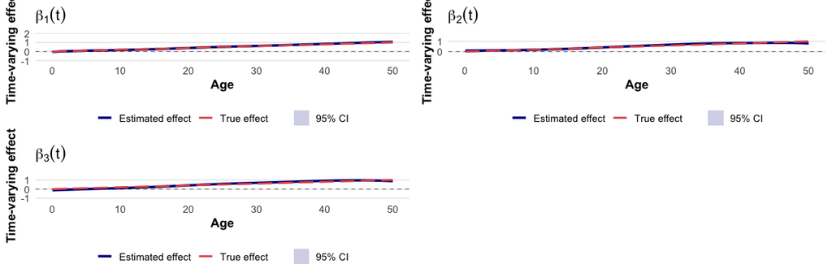

```r
plot(result_joint3)
```

## Next Steps

### Learn More

- **Univariable FMR**: See `vignette("univariable-fmr")` for single exposure analysis
- **Advanced examples**: Check `inst/examples/test_MV-FMR.R` for complete scenarios
- **Manuscript**: See paper for methodological details

## Citation

If you use this package, please cite:

> Fontana, N., Ieva, F., Zuccolo, L., Di Angelantonio, E., & Secchi, P. (2025). Unraveling time-varying causal effects of multiple exposures: integrating Functional Data Analysis with Multivariable Mendelian Randomization. *arXiv preprint arXiv:2512.19064*.